# Final Project

David Deans

June 13, 2019

```r
#Set theme to dust using ggthemr
ggthemr('dust')
```

# 1 Data Review

## 1.1 Load Data

```r
# Load data
dat <- read.csv("Under_Armour.csv")
#Look at the head of both datasets
```

## 1.2 Data Conversion

### 1.2.1 Split dataset and convert to numeric

```r
# Create name vector of true factor variables so can leave them out of numeric conversions
fact_var <- c("Cluster", "PurchApp", "UAPurch", "myself", "significanto", "child", "father", "brother", "friend", "femalefammem",
              "womennofam", "sportsbra", "headwear", "footwear", "shirt", "shorts", "outerwear", "pants", "other")

#create numeric data
dat_num <- dat %>%
  # Remove true factor variables
  select(-fact_var) %>%

  #Convert likert scale variables from section 1 survey data to character numbers
  mutate_all(list( ~str_replace(., "strongly disagree", "1"))) %>%
  mutate_all(list( ~str_replace(., "moderately disagree", "2"))) %>%
  mutate_all(list( ~str_replace(., "slightly disagree", "3"))) %>%
  mutate_all(list( ~str_replace(., "neutral", "4"))) %>%
  mutate_all(list( ~str_replace(., "slightly agree", "5"))) %>%
  mutate_all(list( ~str_replace(., "moderately agree", "6"))) %>%
  mutate_all(list( ~str_replace(., "strongly agree", "7"))) %>%

  #Convert likert scale variables from marketing effects to character numbers
  mutate_all(list( ~str_replace(., "strong negative influence", "1"))) %>%
  mutate_all(list( ~str_replace(., "moderate negative influence", "2"))) %>%
  mutate_all(list( ~str_replace(., "slight negative influence", "3"))) %>%
  mutate_all(list( ~str_replace(., "no influence", "4"))) %>%
  mutate_all(list( ~str_replace(., "slight positive influence", "5"))) %>%
  mutate_all(list( ~str_replace(., "moderate positive influence", "6"))) %>%
  mutate_all(list( ~str_replace(., "strong positive influence", "7")))
```

### 1.2.2 Income conversions

```r
#Convert income to NA
dat_num$income[dat_num$income == "prefer not to answer"] <- NA
#Convert income to numeric
dat_num$income <- str_replace(dat_num$income, "below 20,000", "1")
dat_num$income <- str_replace(dat_num$income, "20,000-39,999", "2")
dat_num$income <- str_replace(dat_num$income, "40,000-59,999", "3")
dat_num$income <- str_replace(dat_num$income, "60,000-79,999", "4")
dat_num$income <- str_replace(dat_num$income, "80,000-99,999", "5")
dat_num$income <- str_replace(dat_num$income, "100,000-149,999", "6")
dat_num$income <- str_replace(dat_num$income, "150,000-199,999", "7")
dat_num$income <- str_replace(dat_num$income, "200,000 or above", "8")
```

### 1.2.3 Convert to numerics and factors, and bind cols

```r
# Convert remaining character variables to numeric
dat_num <- dat_num %>%
  mutate_if(is.character,as.numeric)
# Convert chars to factors for our true factors
dat_fact <- dat %>%
  select(fact_var) %>%
  mutate_if(is.character, as.factor)
#Combine both numerical and factor data into one data
data <- bind_cols(dat_num, dat_fact)
```

## 1.3 Remove NAs

### 1.3.1 Check how many NAs are in our dataset

```r
#Return whether we have any  NAs in our dataset (True = we do have NAs)
any(is.na(data))
```

[1] TRUE

```r
#Check or NAs
#str(data)
#Remove "filter_." ... col full of NAs
data <- data[-60]
#Check Nas by col
colSums(is.na(data))
```

brandatt1 brandatt2 brandatt3 Cause1 Cause2 2 2 3 4 0 Cause3 compan1 compan2 compan3 CSR1 0 2 1 4 0 CSR2 CSR3 environ1 environ2 environ3 4 0 0 5 1 knowledge1 knowledge2 knowledge3 materialism1 materialism2 0 0 1 1 0 materialism3 physfit1 physfit2 physfit3 Prodaest1 0 1 1 0 6 Prodaest2 Prodaest3 Prodaest4 Prodqual1 Prodqual2 2 2 1 2 2 Prodqual3 Prodvalue1 Prodvalue2 prodpur1 prodpur2 0 2 3 0 1 prodpur3 Success1 Success2 Success3 Success4 1 1 0 0 3 UAIntent1 UAIntent2 UAIntent3 Online Retail 2 6 2 1 1 ExPerWeek ExTime AdAthlete family infoblog 0 0 1 2 1 adgen sale magad market onlinead 1 1 2 3 1 peers TVAd age income Cluster 2 2 0 55 7 PurchApp UAPurch myself significanto child 0 2 3 3 4 father brother friend femalefammem womennofam 3 3 3 3 3 sportsbra headwear footwear shirt shorts 4 4 4 4 5 outerwear pants other 4 4 4

### 1.3.2 Clean data of NAs

```r
#Check number of rows with NAs
nrow(data)
```

[1] 230

```r
#Remove rows that contain NAs
data_clean <- na.omit(data)
#Check number of rows without NAs
nrow(data_clean)
```

[1] 130

```r
#Check for NAs
sum(is.na(data_clean))
```

[1] 0

```r
#Read data_clean
#head(data_clean)
#Read data_clean back into data
data <- data_clean
#head(data)
```

# 2 Preliminary EDA

Now that we have sorted our data and cleaned it of NAs, it’s time to take a look at the questions we are hoping to answer over this project. Before beginning its important to remember a few key facts about this case:

1. This survey only includes female Under Armour customers.
2. Under Armour began this market research due to poor performance from their initial launch of the women’s apparel lines.
3. We are specifically looking at our exercise and sports apparel, but that may not be our key selling point / loss point.
4. Most apparel consumption is driven by materialistic or hedonistic values

## 2.1 Questions for Exploration

1. Are female Under Armour consumers primarily anti-materialists, hedonists, environmentalists, or fitness enthusiasts?
2. Does consumer knowledge of product performance impact brand attitude?
3. Does consumer knowledge of product performance impact motivate purchases?
4. Should Under Armour sell to brick-and-mortar or online?
5. What type of advertising and promotions help sales the most?
6. Are there different segments in the female Under Armour market?

## 2.2 Variable Choices

There are many variables that are on similar topics that can be used to cover that topic entirely. One example is “I like Under Armour” and “I think Under Armour is a good brand” (Brandatt1 and Brandatt2). These are repetitive so we do not need to use both.

# 3 Base EDA

## 3.1 Univariate Non-Graphical EDA

```r
#Inspect descriptive statistics of data (dfSummary)
#Warning, large chart, but useful information
# dfSummary(data, plain.ascii = FALSE, style = "grid",
#         graph.magnif = 0.75, tmp.img.dir = "/tmp")
```

```r
#Inspect descriptive statistics of data (Traditional method)
head(data)
```

brandatt1 brandatt2 brandatt3 Cause1 Cause2 Cause3 compan1 compan2 1 6 5 6 6 6 7 7 6 3 6 7 6 6 5 7 6 6 4 5 5 5 6 6 7 6 6 6 7 7 7 7 7 7 7 7 8 6 6 6 5 5 5 5 5 9 4 4 5 6 4 6 6 6 compan3 CSR1 CSR2 CSR3 environ1 environ2 environ3 knowledge1 knowledge2 1 7 7 4 4 7 7 7 5 6 3 7 6 6 6 6 5 6 7 5 4 7 7 7 7 7 7 7 7 5 6 7 7 7 7 7 7 7 7 7 8 5 5 4 5 5 5 5 6 7 9 7 5 5 6 5 6 6 5 4 knowledge3 materialism1 materialism2 materialism3 physfit1 physfit2 1 6 4 1 1 7 7 3 6 6 3 6 7 7 4 5 4 2 5 7 7 6 7 3 1 2 7 7 8 6 4 4 4 7 7 9 4 4 4 4 7 7 physfit3 Prodaest1 Prodaest2 Prodaest3 Prodaest4 Prodqual1 Prodqual2 1 6 5 4 4 5 7 5 3 7 7 5 6 6 7 6 4 5 3 5 5 5 7 7 6 7 4 7 7 7 7 7 8 7 7 5 6 4 7 7 9 5 4 4 4 5 6 6 Prodqual3 Prodvalue1 Prodvalue2 prodpur1 prodpur2 prodpur3 Success1 1 6 5 4 6 6 6 4 3 6 6 6 7 7 7 7 4 6 6 5 7 7 7 4 6 7 7 5 7 7 7 7 8 7 7 6 7 7 6 5 9 4 4 4 5 4 4 5 Success2 Success3 Success4 UAIntent1 UAIntent2 UAIntent3 Online Retail 1 4 5 6 5 5 6 4 4 3 4 3 7 7 7 7 7 7 4 4 5 6 5 5 5 5 6 6 7 3 7 7 7 7 4 7 8 4 5 6 6 6 6 2 7 9 4 4 5 4 4 4 3 4 ExPerWeek ExTime AdAthlete family infoblog adgen sale magad market 1 3 30 4 6 4 4 7 4 4 3 6 120 5 7 1 6 7 6 5 4 6 180 4 7 6 5 7 3 4 6 6 120 7 7 4 7 7 4 7 8 6 120 4 4 2 4 6 5 4 9 5 120 4 7 4 4 5 4 4 onlinead peers TVAd age income Cluster PurchApp UAPurch 1 4 6 4 22 6 Environmentalists yes no 3 5 7 6 19 6 Hedonists yes yes 4 3 5 4 18 1 Environmentalists yes yes 6 4 7 7 19 5 Environmentalists yes yes 8 3 4 4 18 7 Fitness Enthusiasts yes yes 9 4 6 5 20 5 Fitness Enthusiasts yes yes myself significanto child father brother friend femalefammem womennofam 1 no no no no no no no no 3 yes no no yes yes yes yes yes 4 yes no no no no no no no 6 yes no no no no no no no 8 yes no no no no no no no 9 yes no no no no no no no sportsbra headwear footwear shirt shorts outerwear pants other 1 no no no no no no no no 3 no no no yes yes yes yes no 4 no no no no no yes no no 6 yes no no yes no no yes no 8 yes no no yes yes no no yes 9 yes no yes yes yes no yes no

```r
summary(data)
```

brandatt1 brandatt2 brandatt3 Cause1  
Min. :3.000 Min. :1.000 Min. :1.000 Min. :1.000  
1st Qu.:4.000 1st Qu.:4.000 1st Qu.:4.000 1st Qu.:5.000  
Median :6.000 Median :5.500 Median :5.000 Median :6.000  
Mean :5.492 Mean :5.408 Mean :5.231 Mean :5.631  
3rd Qu.:6.000 3rd Qu.:6.000 3rd Qu.:6.000 3rd Qu.:7.000  
Max. :7.000 Max. :7.000 Max. :7.000 Max. :7.000  
Cause2 Cause3 compan1 compan2  
Min. :1.000 Min. :4.000 Min. :2.000 Min. :2.0  
1st Qu.:4.000 1st Qu.:5.000 1st Qu.:6.000 1st Qu.:5.0  
Median :5.000 Median :6.500 Median :6.000 Median :6.0  
Mean :5.146 Mean :6.108 Mean :6.154 Mean :5.8  
3rd Qu.:6.000 3rd Qu.:7.000 3rd Qu.:7.000 3rd Qu.:7.0  
Max. :7.000 Max. :7.000 Max. :7.000 Max. :7.0  
compan3 CSR1 CSR2 CSR3  
Min. :4.000 Min. :2.000 Min. :2.000 Min. :4.000  
1st Qu.:7.000 1st Qu.:6.000 1st Qu.:5.000 1st Qu.:5.250  
Median :7.000 Median :7.000 Median :6.000 Median :6.000  
Mean :6.692 Mean :6.169 Mean :5.892 Mean :6.138  
3rd Qu.:7.000 3rd Qu.:7.000 3rd Qu.:7.000 3rd Qu.:7.000  
Max. :7.000 Max. :7.000 Max. :7.000 Max. :7.000  
environ1 environ2 environ3 knowledge1  
Min. :1.0 Min. :2.000 Min. :1.000 Min. :1.000  
1st Qu.:5.0 1st Qu.:6.000 1st Qu.:6.000 1st Qu.:5.000  
Median :6.0 Median :7.000 Median :7.000 Median :6.000  
Mean :6.1 Mean :6.231 Mean :6.246 Mean :5.923  
3rd Qu.:7.0 3rd Qu.:7.000 3rd Qu.:7.000 3rd Qu.:7.000  
Max. :7.0 Max. :7.000 Max. :7.000 Max. :7.000  
knowledge2 knowledge3 materialism1 materialism2 Min. :2.000 Min. :1.000 Min. :1.000 Min. :1.0  
1st Qu.:5.000 1st Qu.:5.000 1st Qu.:2.000 1st Qu.:2.0  
Median :6.000 Median :6.000 Median :3.000 Median :3.0  
Mean :5.685 Mean :5.838 Mean :3.315 Mean :3.3  
3rd Qu.:7.000 3rd Qu.:7.000 3rd Qu.:4.000 3rd Qu.:4.0  
Max. :7.000 Max. :7.000 Max. :7.000 Max. :7.0  
materialism3 physfit1 physfit2 physfit3  
Min. :1.000 Min. :3.000 Min. :4.000 Min. :4.000  
1st Qu.:3.250 1st Qu.:6.250 1st Qu.:7.000 1st Qu.:6.000  
Median :5.000 Median :7.000 Median :7.000 Median :7.000  
Mean :4.515 Mean :6.654 Mean :6.731 Mean :6.477  
3rd Qu.:6.000 3rd Qu.:7.000 3rd Qu.:7.000 3rd Qu.:7.000  
Max. :7.000 Max. :7.000 Max. :7.000 Max. :7.000  
Prodaest1 Prodaest2 Prodaest3 Prodaest4  
Min. :1.000 Min. :1.000 Min. :1.00 Min. :2.000  
1st Qu.:4.250 1st Qu.:5.000 1st Qu.:5.00 1st Qu.:5.000  
Median :5.000 Median :6.000 Median :6.00 Median :6.000  
Mean :5.323 Mean :5.431 Mean :5.60 Mean :5.692  
3rd Qu.:6.000 3rd Qu.:7.000 3rd Qu.:6.75 3rd Qu.:7.000  
Max. :7.000 Max. :7.000 Max. :7.00 Max. :7.000  
Prodqual1 Prodqual2 Prodqual3 Prodvalue1  
Min. :4.000 Min. :4.000 Min. :4.000 Min. :1.000  
1st Qu.:6.000 1st Qu.:6.000 1st Qu.:5.000 1st Qu.:4.000  
Median :7.000 Median :7.000 Median :6.000 Median :5.500  
Mean :6.515 Mean :6.331 Mean :6.077 Mean :5.162  
3rd Qu.:7.000 3rd Qu.:7.000 3rd Qu.:7.000 3rd Qu.:6.000  
Max. :7.000 Max. :7.000 Max. :7.000 Max. :7.000  
Prodvalue2 prodpur1 prodpur2 prodpur3  
Min. :1.000 Min. :2.000 Min. :3.000 Min. :3.000  
1st Qu.:4.000 1st Qu.:5.000 1st Qu.:6.000 1st Qu.:6.000  
Median :5.000 Median :6.000 Median :7.000 Median :6.000  
Mean :4.777 Mean :6.015 Mean :6.162 Mean :6.123  
3rd Qu.:6.000 3rd Qu.:7.000 3rd Qu.:7.000 3rd Qu.:7.000  
Max. :7.000 Max. :7.000 Max. :7.000 Max. :7.000  
Success1 Success2 Success3 Success4  
Min. :1.000 Min. :1.000 Min. :1.000 Min. :3.000  
1st Qu.:3.000 1st Qu.:3.000 1st Qu.:4.000 1st Qu.:6.000  
Median :4.000 Median :4.000 Median :5.000 Median :6.000  
Mean :4.277 Mean :4.238 Mean :4.815 Mean :6.115  
3rd Qu.:6.000 3rd Qu.:5.000 3rd Qu.:6.000 3rd Qu.:7.000  
Max. :7.000 Max. :7.000 Max. :7.000 Max. :7.000  
UAIntent1 UAIntent2 UAIntent3 Online  
Min. :1.000 Min. :1.000 Min. :1 Min. :1.000  
1st Qu.:4.000 1st Qu.:4.000 1st Qu.:4 1st Qu.:4.000  
Median :5.000 Median :5.000 Median :5 Median :5.000  
Mean :4.754 Mean :4.831 Mean :5 Mean :4.969  
3rd Qu.:6.000 3rd Qu.:6.000 3rd Qu.:6 3rd Qu.:6.000  
Max. :7.000 Max. :7.000 Max. :7 Max. :7.000  
Retail ExPerWeek ExTime AdAthlete  
Min. :1.000 Min. :1.000 Min. : 20.00 Min. :1.000  
1st Qu.:5.000 1st Qu.:3.000 1st Qu.: 50.00 1st Qu.:4.000  
Median :6.000 Median :5.000 Median : 60.00 Median :5.000  
Mean :5.738 Mean :4.446 Mean : 77.35 Mean :4.715  
3rd Qu.:7.000 3rd Qu.:6.000 3rd Qu.:120.00 3rd Qu.:5.000  
Max. :7.000 Max. :7.000 Max. :180.00 Max. :7.000  
family infoblog adgen sale  
Min. :2.000 Min. :1.000 Min. :1.000 Min. :2.0  
1st Qu.:4.000 1st Qu.:4.000 1st Qu.:5.000 1st Qu.:6.0  
Median :6.000 Median :4.000 Median :5.000 Median :7.0  
Mean :5.492 Mean :4.262 Mean :5.092 Mean :6.5  
3rd Qu.:7.000 3rd Qu.:5.000 3rd Qu.:6.000 3rd Qu.:7.0  
Max. :7.000 Max. :7.000 Max. :7.000 Max. :7.0  
magad market onlinead peers  
Min. :1.000 Min. :1.000 Min. :1.000 Min. :2  
1st Qu.:4.000 1st Qu.:4.000 1st Qu.:4.000 1st Qu.:5  
Median :5.000 Median :5.000 Median :4.000 Median :6  
Mean :4.908 Mean :5.062 Mean :4.485 Mean :6  
3rd Qu.:6.000 3rd Qu.:6.000 3rd Qu.:5.000 3rd Qu.:7  
Max. :7.000 Max. :7.000 Max. :7.000 Max. :7  
TVAd age income Cluster  
Min. :1.000 Min. :18.00 Min. :1.000 Anti-Materialists :20  
1st Qu.:4.000 1st Qu.:20.00 1st Qu.:2.000 Environmentalists :47  
Median :5.000 Median :25.50 Median :3.000 Fitness Enthusiasts:27  
Mean :4.908 Mean :27.07 Mean :3.554 Hedonists :36  
3rd Qu.:6.000 3rd Qu.:33.00 3rd Qu.:5.000  
Max. :7.000 Max. :55.00 Max. :7.000  
PurchApp UAPurch myself significanto child father brother  
no : 0 no :55 no :60 no :116 no :128 no :123 no :125  
yes:130 yes:75 yes:70 yes: 14 yes: 2 yes: 7 yes: 5

friend femalefammem womennofam sportsbra headwear footwear shirt  
no :119 no :122 no :126 no :103 no :121 no :128 no :76  
yes: 11 yes: 8 yes: 4 yes: 27 yes: 9 yes: 2 yes:54

shorts outerwear pants other  
no :109 no :111 no :113 no :119  
yes: 21 yes: 19 yes: 17 yes: 11

### 3.1.1 Comments

We already chewed through a lot of this in the preliminary EDA, but it is time to lay down some thoughts about the data we will be combing through further.

### 3.1.3 A Note on Handling Likert Data

We will be treating this data as Likert item data as opposed to Likert scale data. This means that the data will be observed as ordinal data rather than ratio data. This means we cannot be certain about equal spacing between the points (EX. The average of strongly disagree and slightly disagree cannot be said to be moderately disagree). This is why we are using the medians for the data as well.

## 3.2 Univariate Graphical EDA

### 3.2.1 Factor-based graphs

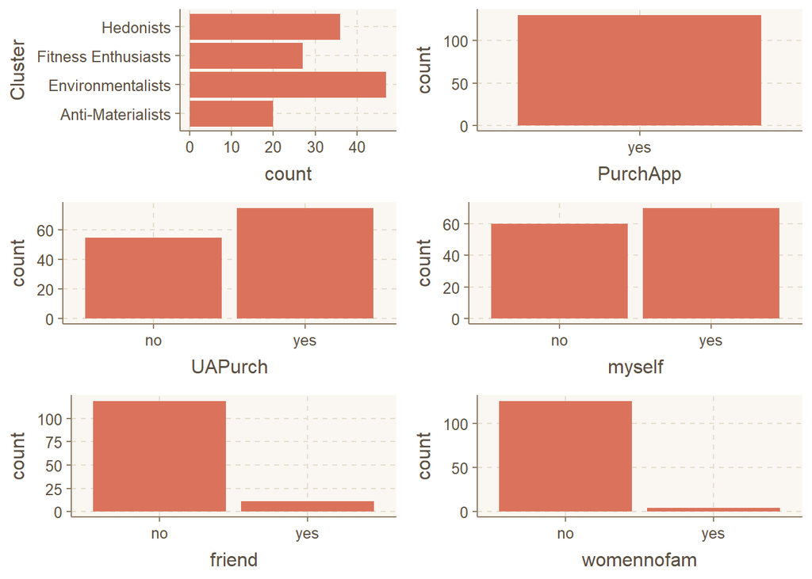

```r
# Using univariate bar graphs with grid.arrange (gridExtra package) to see all quantitative variables together. "x=" is not used because aes() expects x first
 grid.arrange(
    data %>%
      ggplot(aes(Cluster)) +
        geom_bar(position = "dodge") +
        coord_flip(),
    data %>%
      ggplot(aes(PurchApp)) +
        geom_bar(position = "dodge"),

    data %>%
      ggplot(aes(UAPurch)) +
        geom_bar(position = "dodge"),
    data %>%
      ggplot(aes(myself)) +
        geom_bar(position = "dodge"),
    data %>%
      ggplot(aes(friend)) +
        geom_bar(position = "dodge"),
    data %>%
      ggplot(aes(womennofam)) +
        geom_bar(position = "dodge"),
    ncol = 2
  )
```

- PUrchApp is all yes because this is a study revolving around women who have purchased performance sports apparel
- Of that, over half of all participants had purchased a Under Armour product in the past
- Cluster of apparel purchasers from greatest to least
  1. Environmentalists
  2. Hedonists
  3. Fitness Enthusiasts
  4. Anti-Materialists
- Is the proportion of Under Armour purchasers equal across all clusters?
- Is the proportion of self-purchased goods to gift-purchased equal across all clusters?

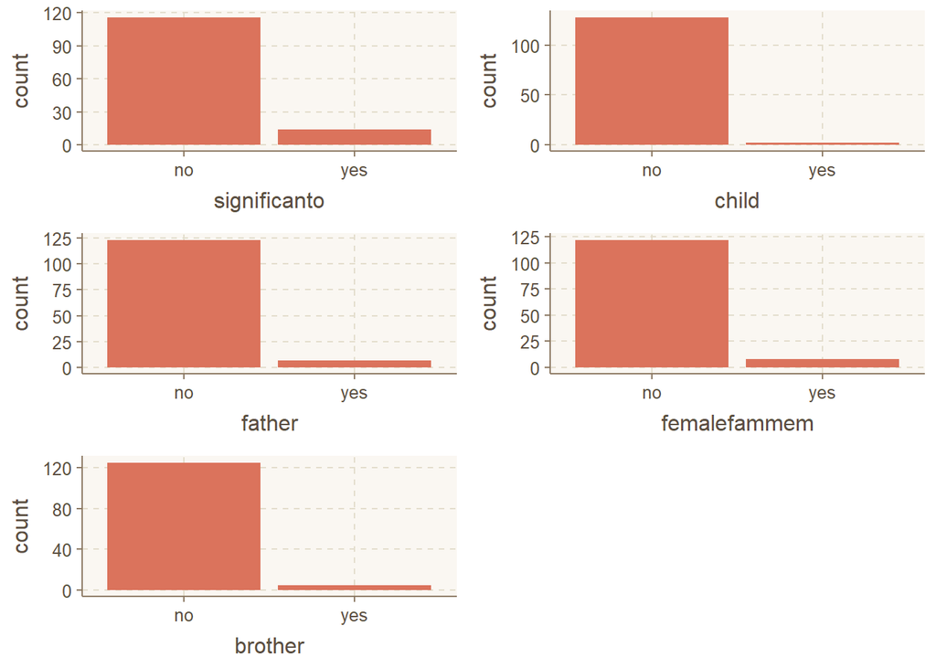

```r
grid.arrange (
  data %>%
    ggplot(aes(significanto)) +
      geom_bar(position = "dodge"),
  data %>%
    ggplot(aes(child)) +
      geom_bar(position = "dodge"),
  data %>%
    ggplot(aes(father)) +
      geom_bar(position = "dodge"),
  data %>%
    ggplot(aes(femalefammem)) +
      geom_bar(position = "dodge"),
  data %>%
    ggplot(aes(brother)) +
      geom_bar(position = "dodge"),
  ncol = 2
)
```

- Separately, people who purchase under armour for other people looks incredibly miniscule
- All gifted purchases together get much closer to 50% of purchases
  - The No option in variable myself is the sum of all other purchase options
- We are primarily interested in the female market segment, so we should focus are continued study there
  - This means focusing on femalefammem, womennofam, and myself
  - sexual identity / orientation and child gender were not recorded so we will be leaving out significanto and child when studying this particular area further

### 3.2.2 Likert Univariate Exploration

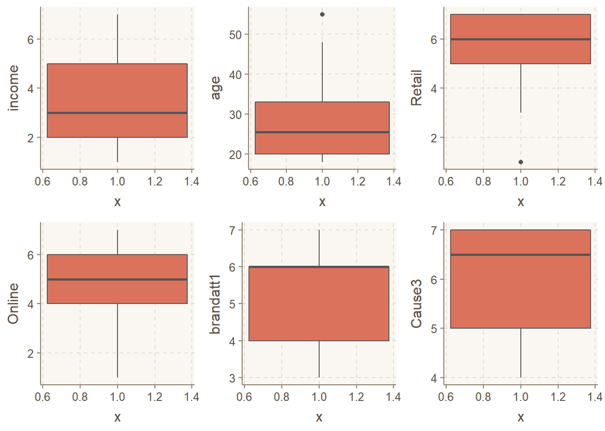

```r
#Taking a look at medians of income, age, shopping choice, UA image, and women's issues
#1 is strongly disagree, 7 is strongly agree, 4 is neutral
grid.arrange(
  data %>%
    ggplot(aes(x = 1, y = income)) +
    geom_boxplot(),
  data %>%
    ggplot(aes(x = 1, y = age)) +
    geom_boxplot(),
  data %>%
    ggplot(aes(x = 1, y = Retail)) +
    geom_boxplot(),
  data %>%
    ggplot(aes(x = 1, y = Online)) +
    geom_boxplot(),
  data %>%
    ggplot(aes(x = 1, y = brandatt1)) +
    geom_boxplot(),
  data %>%
    ggplot(aes(x = 1, y = Cause3)) +
    geom_boxplot(),

  ncol = 3
)
```

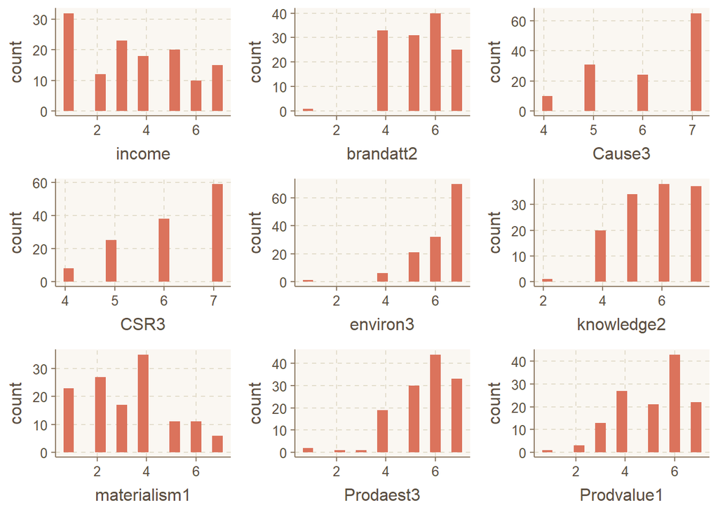

```r
#Taking a look at medians of income, age, shopping choice, UA image, and women's issues
#1 is strongly disagree, 7 is strongly agree, 4 is neutral
grid.arrange(
  data %>%
    ggplot(aes(income)) +
    geom_histogram(bins=15),
  data %>%
    ggplot(aes(brandatt2)) +
    geom_histogram(bins=15),
  data %>%
    ggplot(aes(Cause3)) +
    geom_histogram(bins=15),
  data %>%
    ggplot(aes(CSR3)) +
    geom_histogram(bins=15),
  data %>%
    ggplot(aes(environ3)) +
    geom_histogram(bins=15),
  data %>%
    ggplot(aes(knowledge2)) +
    geom_histogram(bins=15),
  data %>%
    ggplot(aes(materialism1)) +
    geom_histogram(bins=15),
  data %>%
    ggplot(aes(Prodaest3)) +
    geom_histogram(bins=15),
  data %>%
    ggplot(aes(Prodvalue1)) +
    geom_histogram(bins=15),

  ncol = 3
)
```

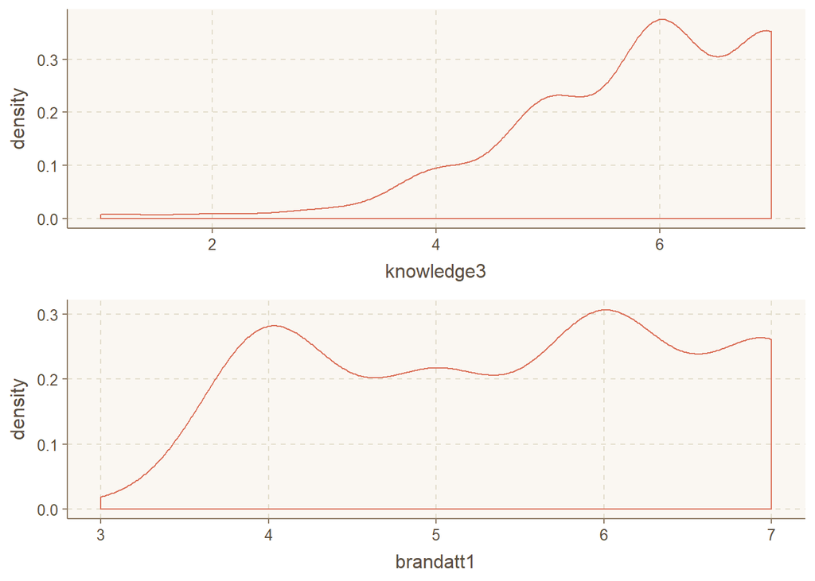

```r
#Density curves
# 2. Does consumer knowledge of product performance impact brand attitude?

grid.arrange(
  data %>%  #I understand the benefits of wearing performance sports apparel
    ggplot(aes(knowledge3)) +
    geom_density(),
  data %>%  #I think Under Armour is a good brand
    ggplot(aes(brandatt1)) +
    geom_density(),
  ncol = 1
)
```

#### 3.2.2.1 Takeaways

- 50% of applicants have a household income of $59,999 or below. This is the 3rd lowest income option.
- Any participant older than 50 is an outlier. 50% of participants are between 20 and about 30 years of age.
- Almost everyone feels neutral to strongly agreed that Under Armour is a desirable brand.
- Most people disagreed that materialism is very important to them.
  - I think hedonism data is going to be hard to track because most people probably are unable to accurately assess negative characteristics about themselves
  - This however means we should probably avoid making our image based on material wealth
- Most people believe they will benefit from wearing performance sports apparel
  - This is unsurprising because it is a survey of people who have purchased performance sports apparel
- Most people agreed that they wanted a product with a good aesthetic and value for money.

## 3.3 Multivariate Non-Graphical EDA

### 3.3.1 Correlations

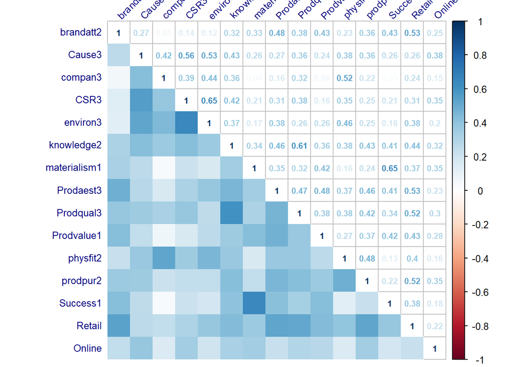

```r
# Survey Questions + Purchasing Intent + Location of Purchase
cor(data[c(2,6,9,12,15,17,19,27,31,32,23,35,37,45,44)],use = "pairwise.complete.obs") %>%
  corrplot.mixed(lower = "shade", upper = "number", tl.pos = "lt", diag = "u", tl.col ="navy", tl.srt = 45, outline = TRUE, tl.cex=.8, number.cex = .7, number.digits = 2,)
```

Across the board positive correlations to the survey data and purchase intent. There were a few standout correlations:

- Holding acquisition of items in high regard(materialism1) had a correlation with placing importance on prestige (success1).
- Wanting socially just companies (Csr3) and finding protecting the environment important (environ3) are highly correlated.
- Supporting women’s issues (Cause3) and expecting social responsibility from companies (Csr3) are highly correlated.
- Placing importance on product quality (Prodqual3) and believing that sports apparel has benefits (Knowledge2) are highly correlated.
- More people intending to purchase products (prodpur2) are interested in Retail (Retail) over Online (Online).
- People who like Under Armour are more likely to shop in store than online.

```r
#Find start position of slice for Marketing and Demographics
which(colnames(data) == "AdAthlete")
```

[1] 48

```r
#Find end position of slice for Marketing and Demographics
which(colnames(data) == "income")
```

[1] 59

[figure not shown]

```r
#Marketing Format + Age + Income
cor(data[c(48:59)],use = "pairwise.complete.obs") %>%
  corrplot.mixed(lower = "shade", upper = "number", tl.pos = "lt", diag = "u", tl.col ="navy", tl.srt = 45, outline = TRUE, tl.cex=.9, number.cex = .9, number.digits = 2,)
```

First the negative relationships. There is a slight negative relationship between age and both TV ads and Advertising in general. Strong positive relationships with Marketing and both Magazines and general Advertising. Advertising with athletes and general advertising have a stronger positive relationship.

[figure not shown]

```r
#Age, Income, Likelihood to Purchase Under Armour, Retail/Online
cor(data[c(35,37,45,44,58,59)],use = "pairwise.complete.obs") %>%
  corrplot.mixed(lower = "shade", upper = "number", tl.pos = "lt", diag = "u", tl.col ="navy", tl.srt = 45, outline = TRUE, tl.cex=.9, number.cex = .9, number.digits = 2,)
```

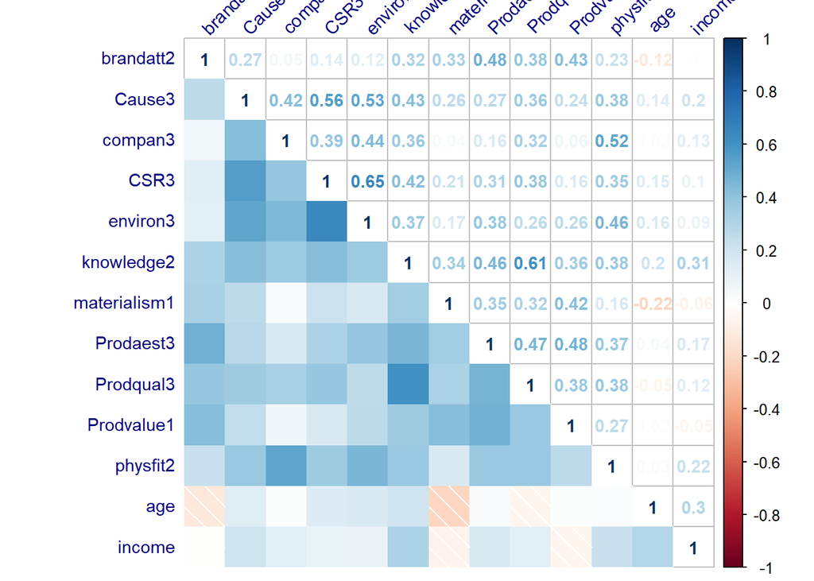

```r
#Age, Income, Under Armour Morality, Environment, Social Causes for self and Company, materialism, productquality, aesthetic
cor(data[c(2,6,9,12,15,17,19,27,31,32,23,58,59)],use = "pairwise.complete.obs") %>%
  corrplot.mixed(lower = "shade", upper = "number", tl.pos = "lt", diag = "u", tl.col ="navy", tl.srt = 45, outline = TRUE, tl.cex=.9, number.cex = .9, number.digits = 2,)
```

Nothing super interesting here. Age and income do not seem to correlate to moral, social, material, or value based decisions. Slight negative relationship between materialism and age. Slight positive relationship between athletic product knowledge and income.

### 3.3.2 Categorical Variables

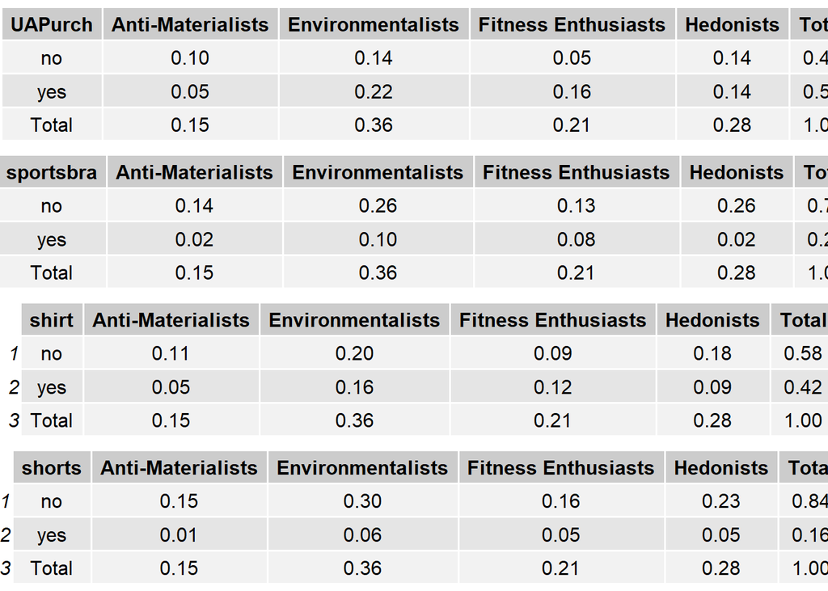

```r
grid.arrange(
#Which Clusters have a higher proportion of Under Armour purchasers?
  tableGrob(
    data %>%
      tabyl(UAPurch,Cluster) %>%
      adorn_totals(where = c("row","col")) %>%
      adorn_percentages(denominator = "all") %>%
      adorn_rounding(2)
),
#Looking at clusters and likelihood to by products. Only using products with a a 15%+ Yes on whether they have purchased or not
# Cluster and sportsbra
  tableGrob(
    data %>%
      tabyl(sportsbra,Cluster) %>%
      adorn_totals(where = c("row","col")) %>%
      adorn_percentages(denominator = "all") %>%
      adorn_rounding(2)
),
# Cluster, shirt
  tableGrob(
    data %>%
      tabyl(shirt,Cluster) %>%
      adorn_totals(where = c("row","col")) %>%
      adorn_percentages(denominator = "all") %>%
      adorn_rounding(2)
),
# Cluster, shorts
  tableGrob(
    data %>%
      tabyl(shorts,Cluster) %>%
      adorn_totals(where = c("row","col")) %>%
      adorn_percentages(denominator = "all") %>%
      adorn_rounding(2)
),
nrow = 4
)
```

## 3.4 Multivariate Graphical EDA

### 3.4.1 1. Are female Under Armour consumers primarily anti-materialists, hedonists, environmentalists, or fitness enthusiasts?

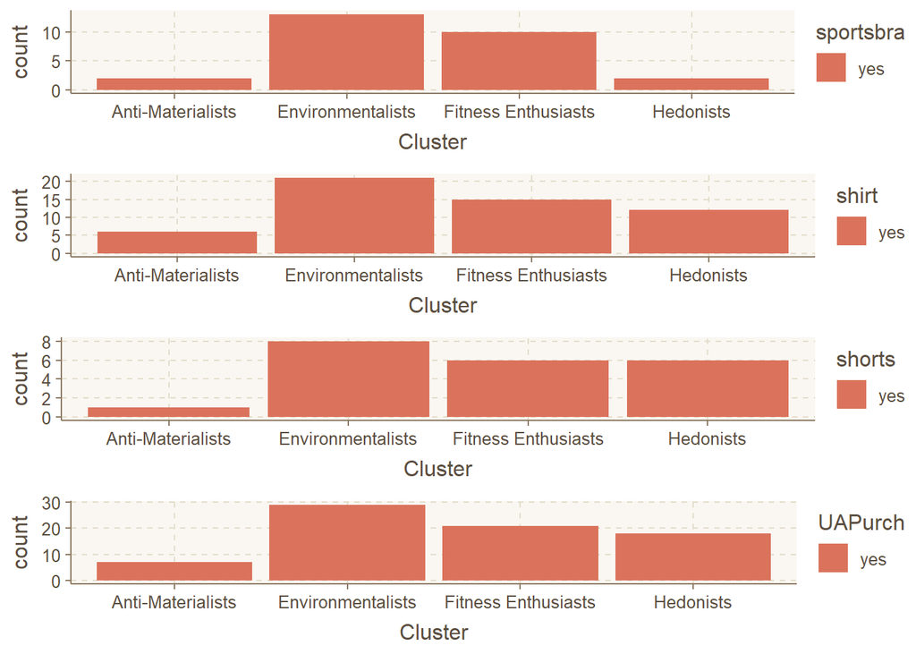

```r
grid.arrange(
  data %>%
    filter(UAPurch == "yes", sportsbra == "yes") %>% #Only include data from people who have purchased sportsbras
    ggplot(aes(Cluster, fill = sportsbra)) +
    geom_bar(position = "stack"),
  data %>%
    filter(UAPurch == "yes", shirt == "yes") %>% #Only include data from people who have purchased shirts
    ggplot(aes(Cluster, fill = shirt)) +
    geom_bar(position = "stack"),
  data %>%
    filter(UAPurch == "yes", shorts == "yes") %>% #Only include data from people who have purchased shorts
    ggplot(aes(Cluster, fill = shorts)) +
    geom_bar(position = "stack"),
  data %>%
    filter(UAPurch == "yes") %>% #Only include data from people who have purchased shorts
    ggplot(aes(Cluster, fill = UAPurch)) +
    geom_bar(position = "stack"),
  ncol = 1
)
```

- Across the 3 chosen forms of clothing Under Armour sells, environmentalists remain their largest category
- Anti-Materialists are not worth focusing on

### 3.4.2 2. Does consumer knowledge of product performance impact brand attitude?

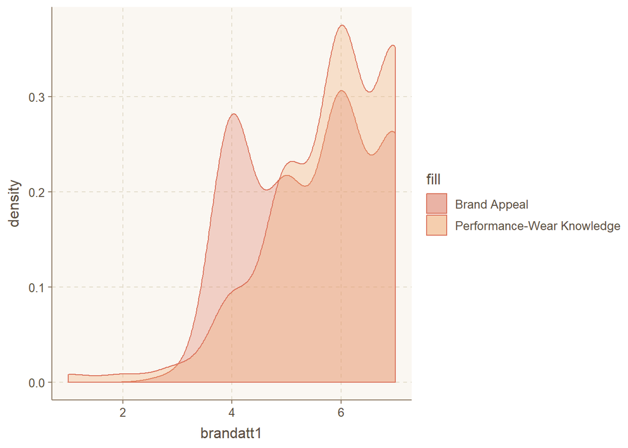

```r
#Create a density scale to look at how each Likert item moves
g <- ggplot() #read into g
g <- g + geom_density(data = data, aes(brandatt1, fill = "Brand Appeal"), alpha = 0.3) #first density curve on Brand Appeal
g <- g + geom_density(data = data, aes(knowledge3, fill = "Performance-Wear Knowledge"), alpha = 0.3) #second density curve on Apparel Knowledge
g #Print Density graph
```

* The densities of Brand Appeal and Performance Apparel knowledge are positively correlated

### 3.4.3 4. Should Under Armour sell to brick-and-mortar or online?

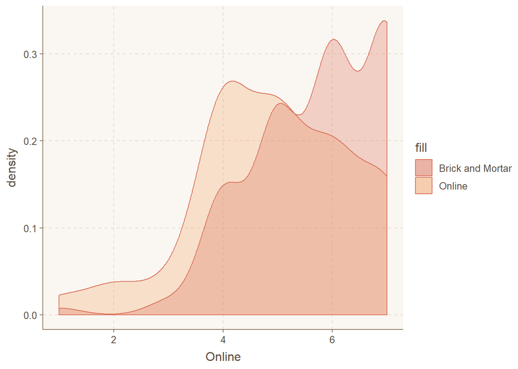

```r
#Create a density scale to look at how each Likert item moves
g <- ggplot() #read into g
g <- g + geom_density(data = data, aes(Online, fill = "Online"), alpha = 0.3) #first density curve on Online
g <- g + geom_density(data = data, aes(Retail, fill = "Brick and Mortar"), alpha = 0.3) #second density curve on Retail
g #Print Density graph
```

* Online peaks at neutral while Brick and Mortar has far more favorable results

### 3.4.4 5. What type of advertising and promotions help sales the most?

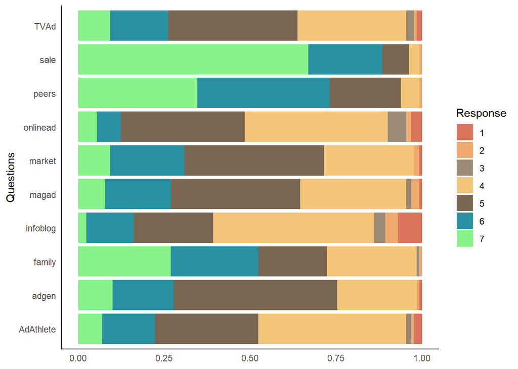

```r
#Convert Likert data into factors to create better graphs
data1 <- data %>%
  select(age)
data2 <- data %>%
  select(-age) %>%
  mutate_if(is.numeric, as.factor)
data <- bind_cols(data1,data2)
datab <- data #for back up and power bi csv write
#Take all advertisement options, list it on the Y axis, fill by the choices 1-7, x axis is just a 100% scale
data %>%
  group_by(`AdAthlete`, `family`, `infoblog`,`adgen`,`sale`,`magad`,`market`,`onlinead`,`peers`,`TVAd`) %>% #Questions and Response
  summarize(n = n()) %>%
  gather(Questions, Response, -c(n)) %>%
  ggplot(mapping = aes(x = Questions, y = n, fill = Response)) +
  geom_bar(stat = "identity", position = "fill") +
  coord_flip() +
    theme_classic() +
  theme(axis.title.x = element_blank(),
        axis.ticks = element_blank())
```

### 3.4.5 Different Market Segments

[figure not shown]

```r
grid.arrange(
  #Under Armour purchasers 24 and younger
data %>%
  select(Cluster, income, age, UAPurch) %>%
  filter(age <= 24 & UAPurch == "yes") %>%
  ggplot(aes(x = income, fill = Cluster)) +
  geom_bar(position = "stack"),
  #Under Armour purchasers years 25 and 34
data %>%
  select(Cluster, income, age, UAPurch) %>%
  filter(age >= 25 & age <= 34 & UAPurch == "yes") %>%
  ggplot(aes(x = income, fill = Cluster)) +
  geom_bar(position = "stack"),
  #Under Armour purchasers years 25 and 34 comparing Environment and Hedonism to everyone else
data %>%
  select(Cluster, income, age, UAPurch) %>%
  filter(age >= 25 & age <= 34 & UAPurch == "yes") %>%
  mutate(Cluster = ifelse(Cluster == "Environmentalists", "Environment and Hedonism",
                   ifelse(Cluster == "Hedonism", "Environment and Hedonism", "Other"))) %>%
  ggplot(aes(x = income, fill = Cluster)) +
  geom_bar(position = "dodge"),
  #Under Armour purchasers 35 and older
data %>%
  select(Cluster, income, age, UAPurch) %>%
  filter(age >= 35 & UAPurch == "yes") %>%
  mutate(Cluster = ifelse(Cluster == "Environmentalists", "Environmentalists", "Other")) %>%
  ggplot(aes(x = income, fill = Cluster)) +
  geom_bar(position = "dodge"),
ncol = 2
)
```

- 20-24 year olds who make below 20,000 a year
- 25-34 year olds who make between 40,000 and 80,000
- 35+ year olds who are Environmentalists
- Under Armour’s primary demographic is 18-24 year olds in general. The 18-24 year olds from different income brackets are nearly identical to those of older ages.
  - Also, rich 18-24 year olds most likely do not exist in the frequency that this data may suggest they are being untapped.

# 4 Detailed EDA

## 4.1 1 Sales, Peers, and Family opinion impact purchase behavior the most

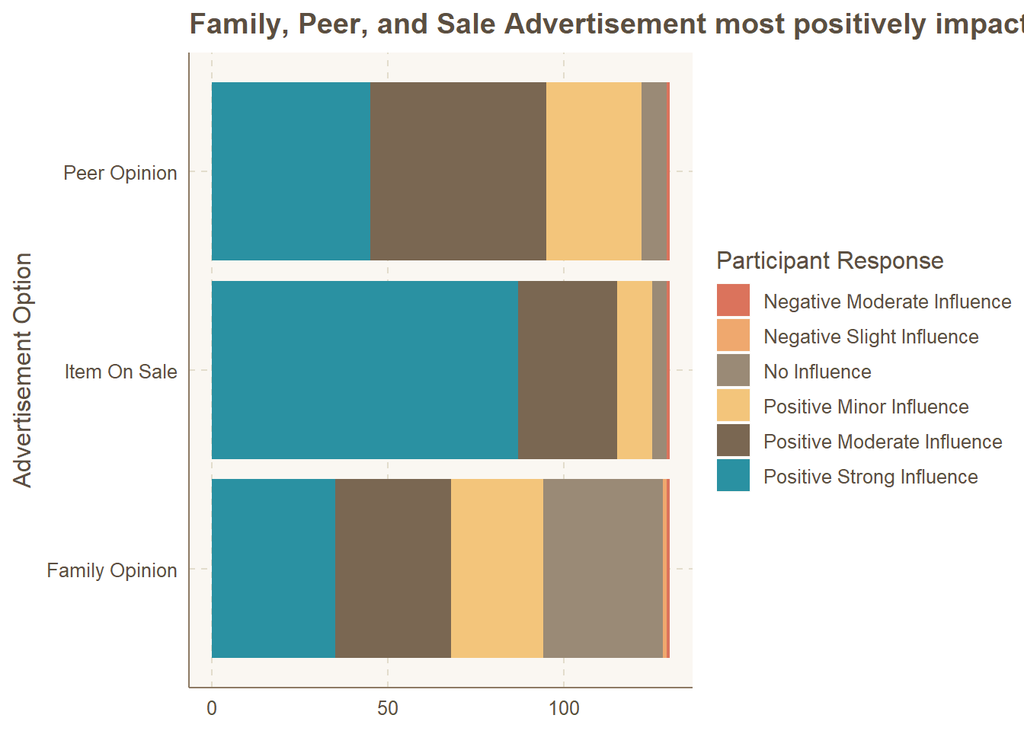

```r
#Take all advertisement options, list it on the Y axis, fill by the choices 1-7, x axis is just a 100% scale
ad_data <- data %>%
  group_by(`family`,`sale`,`peers`) %>%
  summarize(n = n()) %>%
  gather(Advertisement, Response, -c(n)) %>%
  #mutate response to have better legend names
  mutate(Response = ifelse(Response == "1", "Negative Strong Influence",
                    ifelse(Response == "2", "Negative Moderate Influence",
                    ifelse(Response == "3", "Negative Slight Influence",
                    ifelse(Response == "4", "No Influence",
                    ifelse(Response == "5", "Positive Minor Influence",
                    ifelse(Response == "6", "Positive Moderate Influence",
                    ifelse(Response == "7", "Positive Strong Influence", "NULL"
                           ))))))))%>%
  #mutate advertisement to have better names
  mutate(Advertisement = ifelse(Advertisement == "sale","Item On Sale",
                         ifelse(Advertisement == "family","Family Opinion",
                         ifelse(Advertisement == "peers","Peer Opinion", "NULL"
                                ))))%>%
  #plot starts here
  ggplot(mapping = aes(x = Advertisement, y = n, fill = Response)) +
  geom_bar(stat = "identity") +
  coord_flip() +
  theme(axis.title.x = element_blank(),
        axis.ticks = element_blank()) +
     labs(x = "Advertisement Option", title = "Family, Peer, and Sale Advertisement most positively impact purchasing", fill = "Participant Response")
ad_data
```

## 4.2 2 Under Armour’s demographic

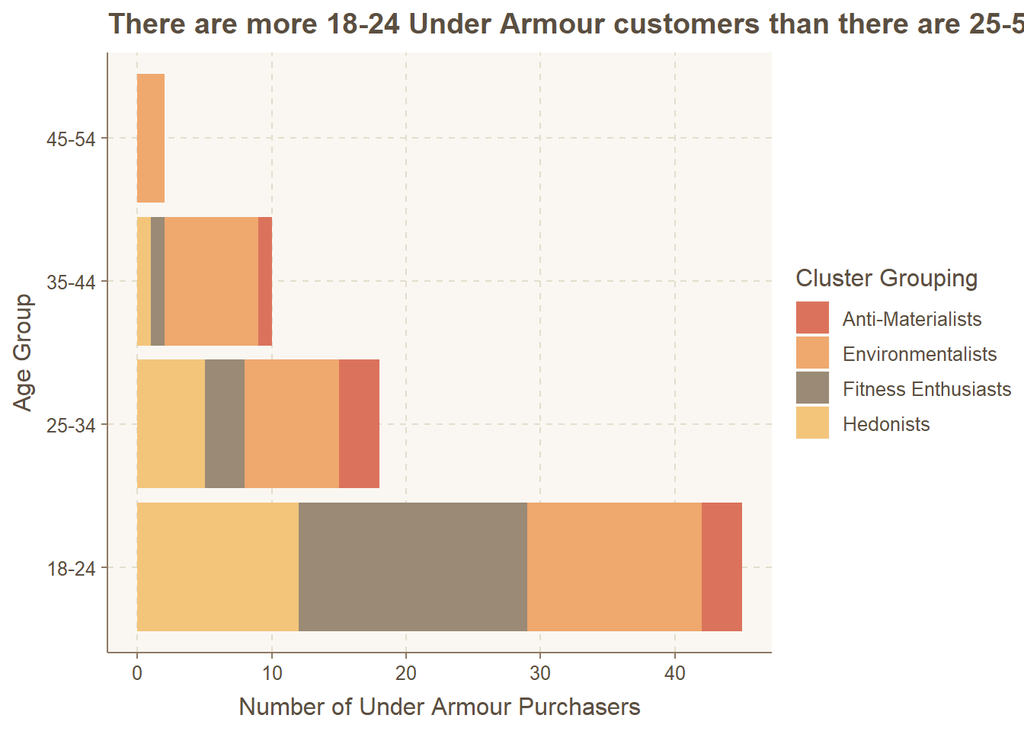

```r
#Convert Age into a categorical function in order to look at market segments
data$fact_age <- cut(data$age, c(18,25,35,45,56),right = FALSE , labels = c(1:4))


demo_data <- data %>%
   select(Cluster, income, fact_age, UAPurch) %>%
   filter(UAPurch == "yes") %>%
   mutate(fact_age = ifelse(fact_age == "1", "18-24",
                     ifelse(fact_age == "2", "25-34",
                     ifelse(fact_age == "3", "35-44",
                     ifelse(fact_age == "4", "45-54","55+"
                            ))))) %>%
   ggplot(aes(x = fact_age, fill = Cluster)) +
   geom_bar(position = "stack") +
   coord_flip() +
     labs(x = "Age Group",y = "Number of Under Armour Purchasers", title = "There are more 18-24 Under Armour customers than there are 25-54", fill = "Cluster Grouping")

demo_data
```

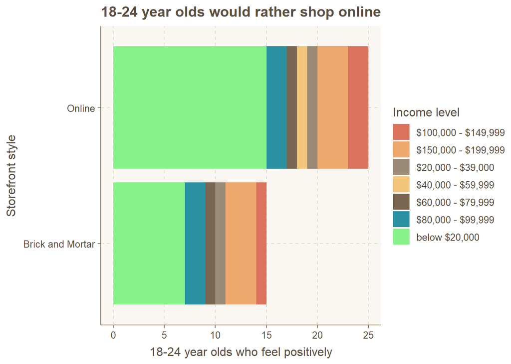

```r
# Does our primary demographic enjoy online or brick and mortar more?
store_data <- data %>%
     mutate(storefront =
                     ifelse(Online == "5", "Online",
                     ifelse(Online == "6", "Online",
                     ifelse(Online == "7", "Online",
                     ifelse(Retail == "5", "Brick and Mortar",
                     ifelse(Retail == "6", "Brick and Mortar",
                     ifelse(Retail == "7", "Brick and Mortar","Other"
                     ))))))) %>%
     mutate(income =
                     ifelse(income == "1", "below $20,000",
                     ifelse(income == "2", "$20,000 - $39,000",
                     ifelse(income == "3", "$40,000 - $59,999",
                     ifelse(income == "4", "$60,000 - $79,999",
                     ifelse(income == "5", "$80,000 - $99,999",
                     ifelse(income == "6", "$100,000 - $149,999",
                     ifelse(income == "7", "$150,000 - $199,999","$200,000 or above"
                     )))))))) %>%
     filter(UAPurch == "yes" & fact_age == "1" & (storefront == "Online" | storefront == "Brick and Mortar")) %>%
   ggplot(aes(x = storefront, fill = income)) +
   geom_bar(position = "stack") +
   coord_flip() +
     labs(x = "Storefront style",y = "18-24 year olds who feel positively", title = "18-24 year olds would rather shop online", fill = "Income level")

store_data
```

# 5 Statistical EDA

Will be reusing the corrplots from earlier and looking into the correlation. Will be using data_clean instead of data because it is cleaned of NAs and still has numeric values.

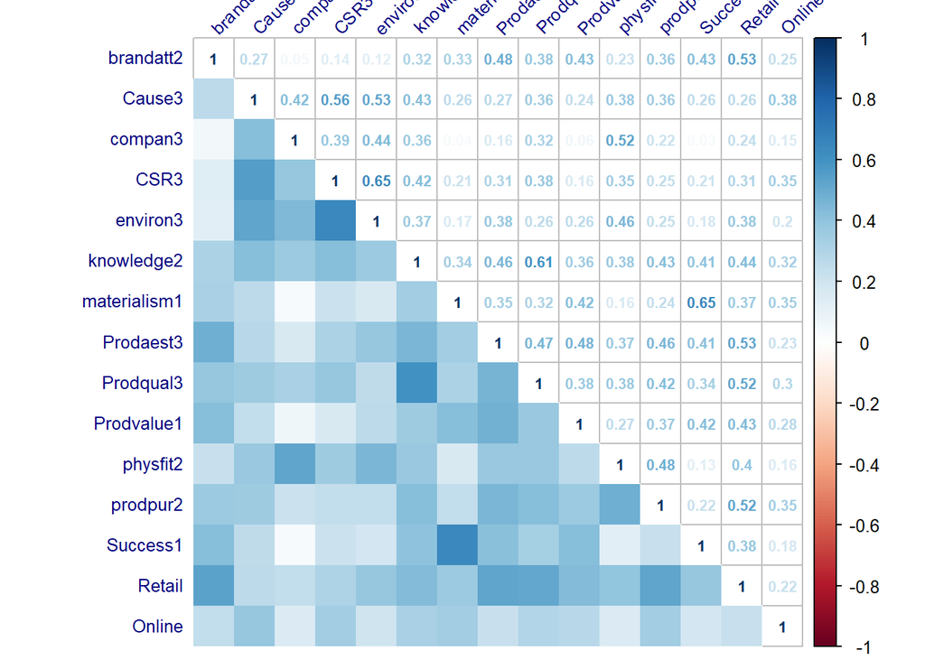

```r
# Survey Questions + Purchasing Intent + Location of Purchase
cor(data_clean[c(2,6,9,12,15,17,19,27,31,32,23,35,37,45,44)],use = "pairwise.complete.obs") %>%
  corrplot.mixed(lower = "shade", upper = "number", tl.pos = "lt", diag = "u", tl.col ="navy", tl.srt = 45, outline = TRUE, tl.cex=.8, number.cex = .7, number.digits = 2,)
```

* Brand Image and Knowledge of Performance Apparel do not seem to be highly correlated, at 0.32. * People who are more Hedonistic (Success1) are more likely to enjoy Retail shopping than they are to enjoy Online shopping

```r
#Find start position of slice for Marketing and Demographics
which(colnames(data_clean) == "AdAthlete")
```

[1] 48

```r
#Find end position of slice for Marketing and Demographics
which(colnames(data_clean) == "income")
```

[1] 59

[figure not shown]

```r
#Marketing Format + Age + Income
cor(data_clean[c(48:59)],use = "pairwise.complete.obs") %>%
  corrplot.mixed(lower = "shade", upper = "number", tl.pos = "lt", diag = "u", tl.col ="navy", tl.srt = 45, outline = TRUE, tl.cex=.9, number.cex = .9, number.digits = 2,)
```

[figure not shown]

```r
#Age, Income, Likelihood to Purchase Under Armour, Retail/Online
cor(data_clean[c(35,37,45,44,58,59)],use = "pairwise.complete.obs") %>%
  corrplot.mixed(lower = "shade", upper = "number", tl.pos = "lt", diag = "u", tl.col ="navy", tl.srt = 45, outline = TRUE, tl.cex=.9, number.cex = .9, number.digits = 2,)
```

- People who intend to purchase performance sports apparel overrall are more likely to go in-store to purchase it

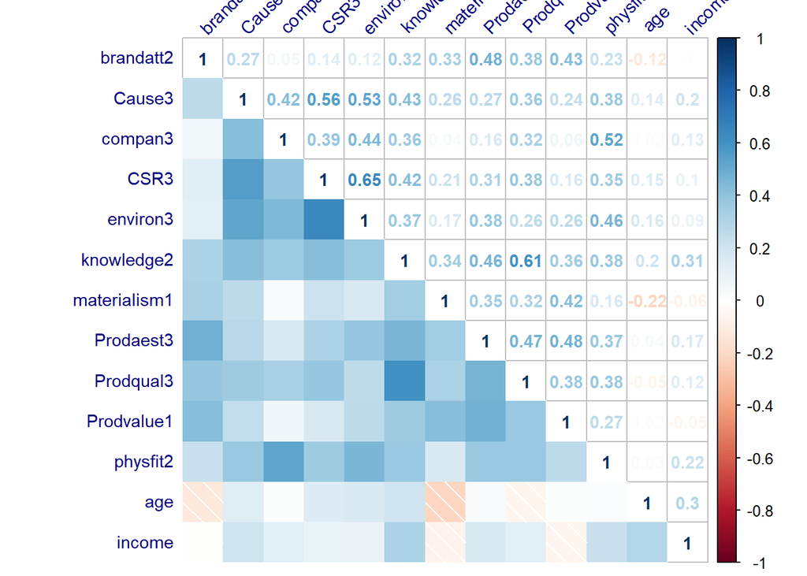

```r
#Age, Income, Under Armour Morality, Environment, Social Causes for self and Company, materialism, productquality, aesthetic
cor(data_clean[c(2,6,9,12,15,17,19,27,31,32,23,58,59)],use = "pairwise.complete.obs") %>%
  corrplot.mixed(lower = "shade", upper = "number", tl.pos = "lt", diag = "u", tl.col ="navy", tl.srt = 45, outline = TRUE, tl.cex=.9, number.cex = .9, number.digits = 2,)
```

# 6 Save graphs for use in memo

```r
# Can load into other documents like any other .png file
ggsave("store_data.png", plot = store_data, scale = .8)
ggsave("demo_data.png", plot = demo_data, scale = .8)
ggsave("ad_data.png", plot = ad_data, scale = .8)
write.csv(datab,"powerbidata.csv")
```